# DSCI 100 Final Project Report

## Introduction

Cardiovascular disease is the leading cause of death across the world for both men and women. The diagnosis of heart disease is often based on previous experience of diagnosing patients with similar symptoms, signs, physical examinations and current clinical tests. Several factors, such as smoking habits, body cholesterol levels, obesity, high blood pressure and lack of physical exercise increase the risk of heart disease. Patients suffering from heart disease require timely diagnosis of their condition, early treatment and constant observation. A difficult challenge that health organizations, namely hospitals and medical centers face, is the efficient diagnosis of patients through non-expensive and non-invasive means. Our model aims to extract patterns and relationships by identifying classifiers with the highest accuracy associated with heart disease from previously collected data to predict whether or not a patient has heart disease; therefore, it can be helpful to medical professionals to make timely clinical diagnoses and decisions.

For the purposes of our analysis, we will define a patient having heart disease as fatty plaques narrowing the diameter of blood vessels by 50% or greater, as physicians formally diagnose patients with obstructive heart disease at this benchmark because this deems patients at a high enough risk of a heart attack or stroke to warrant preventative measures.

#### Dataset:

In this analysis we will utilize a dataset from the [UCI Machine Learning Repository](https://archive.ics.uci.edu/ml/datasets/Heart+Disease) with data collected by 4 institutes:

1. Hungarian Institute of Cardiology. Budapest: Andras Janosi, M.D.
2. University Hospital, Zurich, Switzerland: William Steinbrunn, M.D.
3. University Hospital, Basel, Switzerland: Matthias Pfisterer, M.D.
4. V.A. Medical Center, Long Beach and Cleveland Clinic Foundation: Robert Detrano, M.D., Ph.D.

#### Question: Given a set of factors pertaining to an individual, will they have heart disease?

## Methods and Results

First, we load the relevent libraries that we will use in our analysis.

```r
set.seed(111)
options(repr.matrix.max.rows = 6)

library(tidyverse)
library(tidymodels)
library(repr)
library(digest)
library(cowplot)
library(GGally)
library(gridExtra)
```

Next, we need to import the appropriate data into R. Since the data is hosted on the UCI repository, we need to import the data through their webside using the read_csv funcion.

We've decided to exclusively use the data from Cleveland in building our classifier, since it the only dataset in the UCI repository that has been formally used in data anaylsis. This would indicate that the dataset from Cleveland is highly accurate in its data, thus making it reliable. In doing so, we limit the amount of data we have to work with. However, more accurate and reliable data as opposed to more of it is a tradeoff we take in our analysis.

```r
# URL
url_cl <- "https://archive.ics.uci.edu/ml/machine-learning-databases/heart-disease/processed.cleveland.data"
# List of observations
column_headers <- c("age", "sex", "chest_pain", "resting_bp", "chol", "fasting_bs", "resting_ecg", "max_hr", "exangina", "oldpeak", "slope", "ca", "thal", "num")
heart_disease_cleveland <- read_csv(url_cl, col_names = column_headers)
# Write Data - DO NOT RUN unless you want data stored locally.
#write_csv(heart_disease_all, path = "data/HeartDiseaseAllData.csv", append = FALSE)
glimpse(heart_disease_cleveland)
```

```
Rows: 303
Columns: 14
$ age         <dbl> 63, 67, 67, 37, 41, 56, 62, 57, 63, 53, 57, 56, 56, 44, 5…
$ sex         <dbl> 1, 1, 1, 1, 0, 1, 0, 0, 1, 1, 1, 0, 1, 1, 1, 1, 1, 1, 0, …
$ chest_pain  <dbl> 1, 4, 4, 3, 2, 2, 4, 4, 4, 4, 4, 2, 3, 2, 3, 3, 2, 4, 3, …
$ resting_bp  <dbl> 145, 160, 120, 130, 130, 120, 140, 120, 130, 140, 140, 14…
$ chol        <dbl> 233, 286, 229, 250, 204, 236, 268, 354, 254, 203, 192, 29…
$ fasting_bs  <dbl> 1, 0, 0, 0, 0, 0, 0, 0, 0, 1, 0, 0, 1, 0, 1, 0, 0, 0, 0, …
$ resting_ecg <dbl> 2, 2, 2, 0, 2, 0, 2, 0, 2, 2, 0, 2, 2, 0, 0, 0, 0, 0, 0, …
$ max_hr      <dbl> 150, 108, 129, 187, 172, 178, 160, 163, 147, 155, 148, 15…
$ exangina    <dbl> 0, 1, 1, 0, 0, 0, 0, 1, 0, 1, 0, 0, 1, 0, 0, 0, 0, 0, 0, …
$ oldpeak     <dbl> 2.3, 1.5, 2.6, 3.5, 1.4, 0.8, 3.6, 0.6, 1.4, 3.1, 0.4, 1.…
$ slope       <dbl> 3, 2, 2, 3, 1, 1, 3, 1, 2, 3, 2, 2, 2, 1, 1, 1, 3, 1, 1, …
$ ca          <chr> "0.0", "3.0", "2.0", "0.0", "0.0", "0.0", "2.0", "0.0", "…
$ thal        <chr> "6.0", "3.0", "7.0", "3.0", "3.0", "3.0", "3.0", "3.0", "…
$ num         <dbl> 0, 2, 1, 0, 0, 0, 3, 0, 2, 1, 0, 0, 2, 0, 0, 0, 1, 0, 0, …
```

```r
sample(heart_disease_cleveland)
```

A tibble: 303 × 14

| num <dbl> | slope <dbl> | resting_bp <dbl> | chest_pain <dbl> | exangina <dbl> | chol <dbl> | thal <chr> | ca <chr> | sex <dbl> | age <dbl> | oldpeak <dbl> | resting_ecg <dbl> | fasting_bs <dbl> | max_hr <dbl> |
| --- | --- | --- | --- | --- | --- | --- | --- | --- | --- | --- | --- | --- | --- |
| 0 | 3 | 145 | 1 | 0 | 233 | 6.0 | 0.0 | 1 | 63 | 2.3 | 2 | 1 | 150 |
| 2 | 2 | 160 | 4 | 1 | 286 | 3.0 | 3.0 | 1 | 67 | 1.5 | 2 | 0 | 108 |
| 1 | 2 | 120 | 4 | 1 | 229 | 7.0 | 2.0 | 1 | 67 | 2.6 | 2 | 0 | 129 |
| ⋮ | ⋮ | ⋮ | ⋮ | ⋮ | ⋮ | ⋮ | ⋮ | ⋮ | ⋮ | ⋮ | ⋮ | ⋮ | ⋮ |
| 3 | 2 | 130 | 4 | 1 | 131 | 7.0 | 1.0 | 1 | 57 | 1.2 | 0 | 0 | 115 |
| 1 | 2 | 130 | 2 | 0 | 236 | 3.0 | 1.0 | 0 | 57 | 0.0 | 2 | 0 | 174 |
| 0 | 1 | 138 | 3 | 0 | 175 | 3.0 | ? | 1 | 38 | 0.0 | 0 | 0 | 173 |

*Table 1.1: Sample of "Heart Disease Data Set" from the UCI Machine Learning repository with appropriate column names*

### Predictors

##### Removal of non-numeric data

In order to create the best model, we need to optimize our choice of predictors. We can start by removing non numerical data, since it is too difficult to compute the distance of classes. A solution we tried to use to simplify classes was to assign them values. For example, if an observation can have 3 traits, then we can assign those 3 traits to the numericaL values 1, 2 and 3. However, classes are not always on a spectrum, but can be completely arbitrary and mutually exclusive, meaning that if a trait is more of 3, that does not make it closer to 2 than 1. Therefore, we've decided to remove them.

##### Missing Values

We can observe in *Table 1.1* that the table has each variable in a column, and each observation in a row. However, from the preview above, we can see that the value for some traits of particular observations are the charactor "?", which we can assume are missing values since they don't correspond with the rest of the items in the column. We can eliminate this issue by filtering out all the observations that have a "?" value in a variable/predictor we use.

##### Splitting Sex

In the making of our model, we decided to split our data set by sex, as men and women have different levels of target blood pressure ranges, max heart rates and cholesterol levels. For example, younger women tend to have lower LDL cholesterol levels than young men, then after puberty, women tend to have higher HDL cholesterol levels than men because estrogen boosts cholesterol. Furthermore, women over 55 or who have completed menopause tend to have lower LDL cholesterol levels than men and in general, men tend to have higher HDL cholesterol levels than women. Additionally, women tend to have lower target blood pressure ranges compared to men. Lastly, heart disease tends to develop in women 7 to 10 years later than in men due to exposure to estrogens during the fertile period of life which delays heart disease in women. Therefore, we hypothesis that the physioloigcal differences between men and women may negatively influence predictions made.

```r
# Filters the unknown data in relevant columns and standardizes column types and values
heart_disease_filtered <- filter(heart_disease_cleveland, resting_bp != "?", chol != "?", oldpeak != "?", max_hr != "?", num != "?") %>%
    select(sex, age, max_hr, oldpeak, chol, resting_bp, num) %>%
    mutate(max_hr = as.numeric(max_hr), oldpeak = as.numeric(oldpeak), chol = as.numeric(chol), resting_bp = as.numeric(resting_bp)) %>%
    mutate(num = ifelse(num > 0, 1, 0)) %>%
    mutate(num = factor(num))
```

```r
heart_disease_men <- heart_disease_filtered %>%
    filter(sex == 1) %>%
    select(!sex)
heart_disease_women <- heart_disease_filtered %>%
    filter(sex == 0) %>%
    select(!sex)

heart_disease_men
```

A tibble: 206 × 6

| age <dbl> | max_hr <dbl> | oldpeak <dbl> | chol <dbl> | resting_bp <dbl> | num <fct> |
| --- | --- | --- | --- | --- | --- |
| 63 | 150 | 2.3 | 233 | 145 | 0 |
| 67 | 108 | 1.5 | 286 | 160 | 1 |
| 67 | 129 | 2.6 | 229 | 120 | 1 |
| ⋮ | ⋮ | ⋮ | ⋮ | ⋮ | ⋮ |
| 68 | 141 | 3.4 | 193 | 144 | 1 |
| 57 | 115 | 1.2 | 131 | 130 | 1 |
| 38 | 173 | 0.0 | 175 | 138 | 0 |

*Table 1.2: Tidy set of observations exclusive to men.*

```r
heart_disease_women
```

A tibble: 97 × 6

| age <dbl> | max_hr <dbl> | oldpeak <dbl> | chol <dbl> | resting_bp <dbl> | num <fct> |
| --- | --- | --- | --- | --- | --- |
| 41 | 172 | 1.4 | 204 | 130 | 0 |
| 62 | 160 | 3.6 | 268 | 140 | 1 |
| 57 | 163 | 0.6 | 354 | 120 | 0 |
| ⋮ | ⋮ | ⋮ | ⋮ | ⋮ | ⋮ |
| 63 | 136 | 0.0 | 197 | 124 | 1 |
| 57 | 123 | 0.2 | 241 | 140 | 1 |
| 57 | 174 | 0.0 | 236 | 130 | 1 |

*Table 1.3: Tidy set of observations exclusive to women.*

To ensure that our decision making thus far has been somewhat in line with what we hope to uncover, we'll use a ggpairs comparison with each dataset to check our predictors for correlation with num.

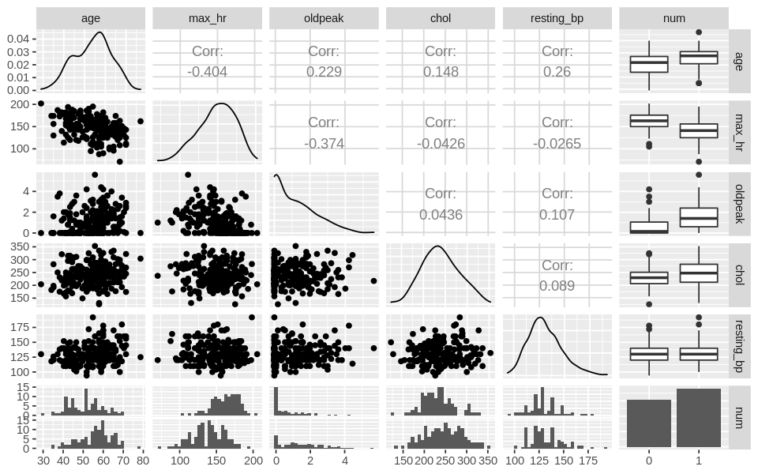

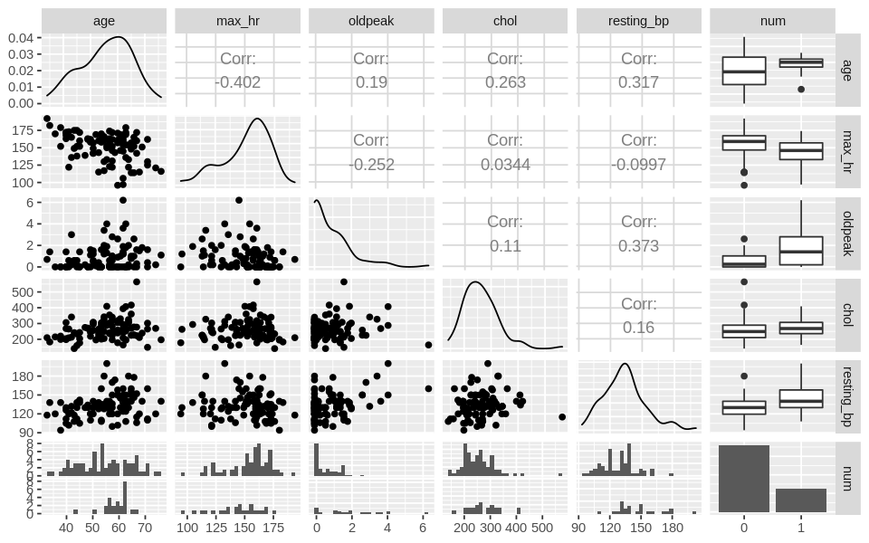

```r
options(repr.plot.width = 8, repr.plot.height = 5)
men_hd_comparison <- heart_disease_men %>% ggpairs()
men_hd_comparison
women_hd_comparison <- heart_disease_women %>% ggpairs()
women_hd_comparison
```

*Graph 1.4.1(Above) and 1.4.2(Below) GGPairs graphs of correlation between predictors*

### Summary

Firstly, we will do some relevant analysis on the data and summarize it into useful statistics and information that may be relevent towards the data analysis.

Since we previously hypothesized that men and woman have different physiological differences, such as cholesterol, we can confirm this by calculating the different averages for the level of cholesterol in both men and woman, as well as the their average cholesterol when they are classified to have heart disease.

```r
chol_avg <- heart_disease_filtered %>%
    select(sex, num, chol) %>%
    mutate(num = ifelse(num == 0, "Without", "With"),
          sex = ifelse(sex == 0, "Women", "Men")) %>%
    group_by(sex, num) %>%
    summarize(mean = mean(chol)) %>%
    pivot_wider(names_from = num, values_from = mean)
chol_avg
```

A grouped_df: 2 × 3

| sex <chr> | With <dbl> | Without <dbl> |
| --- | --- | --- |
| Men | 246.0614 | 231.5978 |
| Women | 276.1600 | 256.7500 |

*Table 2.1: Cholesterol Average of Men and Woman with and without heart disease (Untidy for an easier comparison).*

Shown in table 2.1 above, we can see a strong difference in the average cholesterol levels for men and women. In men without heart disease, we found and average of 231.59 mg/dl in men, while woman had an average of 256.7500 mg/dl. This difference becomes even more distinct when comparing men and woman who are classified to have heart disease. In men with heart disease, they are shown to have an average of 246.06 mg/dl, while in woman they are shown to have an average of 276.16, which is a difference on average of roughly 30 mg/dl. Additionally, by doing this analysis, we can confirm our hypothesis that men and woman have different physiological tolerances, and therefore by seperating the data we can create more accurate classifiers.

It would also be relevent to look at the correlations *between* varibales in our dataset. Here, we can map out the comparison between age and blood pressure in both men and woman to see if there is any correlation.

```r
#RESTING_BP vs AGE
bp_age_plot <- function(df, ttl) {
    df %>%
    select(age, resting_bp) %>%
    ggplot(aes(x = age, y = resting_bp)) +
        geom_point() +
        geom_smooth(method = "lm", se = TRUE) +
        labs(x = "Age", y = "Resting Blood Pressure", title = ttl)
}
```

```r
bpvage_men <- bp_age_plot(heart_disease_men, "Age - Blood Pressure in Men")
#bpvage_men_without <- bp_age_plot(men_without, "Age - Blood Pressure in Men Without Heart Disease")
```

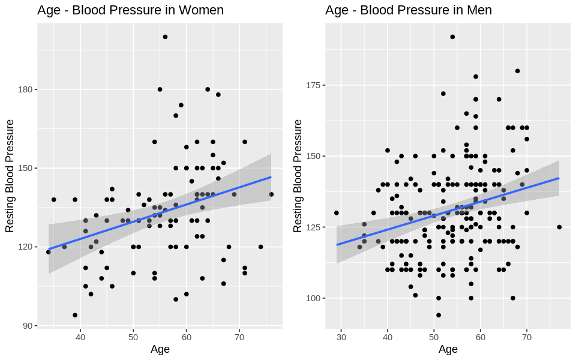

```r
bpvage_women <- bp_age_plot(heart_disease_women, "Age - Blood Pressure in Women")
#bpvage_women_without <- bp_age_plot(women_without, "Age - Blood Pressure in Women Without Heart Disease")
grid.arrange(bpvage_women, bpvage_men, ncol = 2)
```

*Graph 2.2.1 (Left) and 2.2.2 (Right) Age correlation with blood pressure*

Shown in the graphs above, a correlation between age and blood pressure can be found with both men and woman. Our line of best fit demonstrates a positive relationship between the two variables. However, if we look at the points on the graph, they are very spread out and apart from eachtoher. This would indicate that this is a weak positive correlation

Next, lets compare the cholesterol levels versus the age.

```r
#CHOL vs AGE
chol_age_plot <- function(df, ttl) {
    df %>%
    select(age, chol) %>%
    ggplot(aes(x = age, y = chol)) +
        geom_point() +
        geom_smooth(method = "lm", se = TRUE) +
        labs(x = "Age", y = "Cholesterol", title = ttl)
}
```

```r
cholvage_men <- chol_age_plot(heart_disease_men, "Age - Cholesterol in Men")
#cholvage_men_without <- chol_age_plot(men_without, "Age - Cholesterol in Men Without Heart Disease")
```

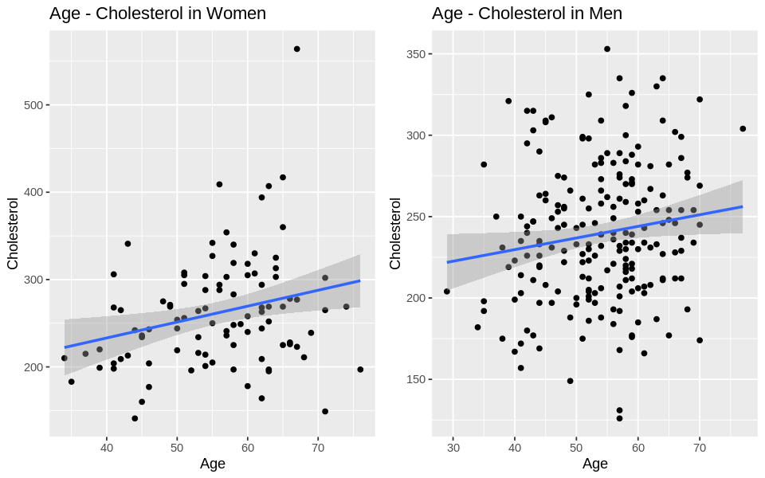

```r
cholvage_women <- chol_age_plot(heart_disease_women, "Age - Cholesterol in Women")
#cholvage_women_without <- chol_age_plot(women_without, "Age - Cholesterol in Women Without Heart Disease")
grid.arrange(cholvage_women, cholvage_men, ncol = 2)
```

*Graph 2.3.1 (Left) and 2.3.2 (Right) Age correlation with cholesterol in both men and woman*

The weak postive correlation between blood pressure and cholesterol translates to a weak positive correlation between higher cholesterol levels and older age, which may be why heart disease becomes more prevelant as an individual ages. This was to be expected as research shows that blood cholesterol concentration increases with age.

Lastly, we will look at the comparison between Oldpeak (ST wave depression induced by exersize compared to rest) versus the Blood Pressure.

```r
#Oldpeak vs Blood Pressure
op_bp_plot <- function (df, ttl) {
    df %>%
    select(oldpeak, resting_bp) %>%
    ggplot(aes(x = resting_bp, y = oldpeak)) +
        geom_point() +
        geom_smooth(method = "lm", se = TRUE) +
        labs(x = "Resting Blood Pressure", y = "ST wave depression induced by exercise relative to rest", title = ttl)
}
```

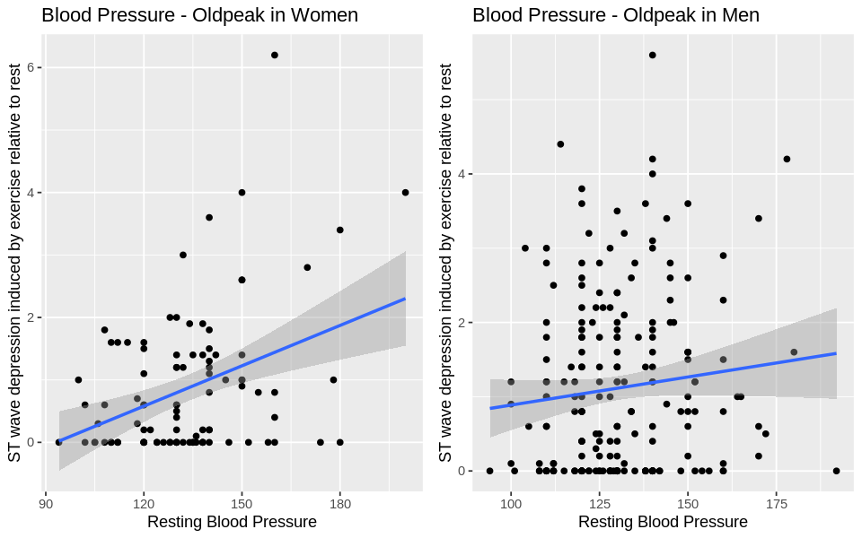

```r
opvbp_men <- op_bp_plot(heart_disease_men, "Blood Pressure - Oldpeak in Men")
#opvbp_men_without <- op_bp_plot(men_without, "Blood Pressure - Oldpeak in Men without Heart Disease")
opvbp_women <- op_bp_plot(heart_disease_women, "Blood Pressure - Oldpeak in Women")
#opvbp_women_without <- op_bp_plot(women_without, "Blood Pressure - Oldpeak in Women without Heart Disease")
grid.arrange(opvbp_women, opvbp_men, ncol = 2)
```

*Graph 2.4.1 and 2.4.2 Blood pressure correlation with oldpeak*

ST wave depression due to exercise can be a reliable method for predicting heart disease, as it is specifically caused by the type of heart disease we are predicting, among other things. The table below shows that individuals with heart disease have significantly higher values than those who don't.

```r
oldpeak_avg <- heart_disease_filtered %>%
    select(sex, num, oldpeak) %>%
    mutate(num = ifelse(num == 0, "Without", "With"),
          sex = ifelse(sex == 0, "Women", "Men")) %>%
    group_by(sex, num) %>%
    summarize(mean = mean(oldpeak)) %>%
    pivot_wider(names_from = num, values_from = mean)
oldpeak_avg
```

A grouped_df: 2 × 3

| sex <chr> | With <dbl> | Without <dbl> |
| --- | --- | --- |
| Men | 1.531579 | 0.6119565 |
| Women | 1.768000 | 0.5541667 |

*Table 2.5 Oldpeak in men and women with and without heart disease*

The table above shows that for both men and woman, the value of oldpeak, or the distance in the ST wave depression compared to rest, is significantly higher in men and woman who have heart disease than in men and woman who do not have it.

#### Building the classifier

We then split our data into a training and testing set. This is done so we can assess the model on how it is going to predict unseen data on new data points that arent labelled. We need to be split our data because if you use the same data that you used to fit the model, your assessment is biased in favour of the model and your model will be more accurate than it is because it has access to the labels.

```r
men_split <- initial_split(data = heart_disease_men, prop = .8, strata = num)
women_split <- initial_split(data = heart_disease_women, prop = .8, strata = num)
```

We use .8 as our proportion value in order to later use a 5 fold cross validation. The .8 proportion allows us to cover our entire dataset, as .2 times 5 is the whole proportion 1.

```r
men_training <- training(men_split)
women_training <- training(women_split)
```

```r
men_testing <- testing(men_split)
women_testing <- testing(women_split)
```

```r
men_training
women_training
```

A tibble: 166 × 6

| age <dbl> | max_hr <dbl> | oldpeak <dbl> | chol <dbl> | resting_bp <dbl> | num <fct> |
| --- | --- | --- | --- | --- | --- |
| 67 | 108 | 1.5 | 286 | 160 | 1 |
| 67 | 129 | 2.6 | 229 | 120 | 1 |
| 37 | 187 | 3.5 | 250 | 130 | 0 |
| ⋮ | ⋮ | ⋮ | ⋮ | ⋮ | ⋮ |
| 45 | 132 | 1.2 | 264 | 110 | 1 |
| 68 | 141 | 3.4 | 193 | 144 | 1 |
| 38 | 173 | 0.0 | 175 | 138 | 0 |

A tibble: 79 × 6

| age <dbl> | max_hr <dbl> | oldpeak <dbl> | chol <dbl> | resting_bp <dbl> | num <fct> |
| --- | --- | --- | --- | --- | --- |
| 57 | 163 | 0.6 | 354 | 120 | 0 |
| 56 | 153 | 1.3 | 294 | 140 | 0 |
| 58 | 162 | 1.0 | 283 | 150 | 0 |
| ⋮ | ⋮ | ⋮ | ⋮ | ⋮ | ⋮ |
| 55 | 166 | 1.2 | 342 | 132 | 0 |
| 63 | 136 | 0.0 | 197 | 124 | 1 |
| 57 | 174 | 0.0 | 236 | 130 | 1 |

*Table 3.1.1 (Above) and 3.1.2 (Below): training data created from modified data set*

We create the model specification, with the mode set to classification since we are trying to classify a value..

```r
knn_tune <- nearest_neighbor(weight_func = "rectangular", neighbors = tune()) %>%
    set_engine("kknn") %>%
    set_mode("classification")
```

We create a function called create_vfold that applies the function vfold_cv to be easily applied to the data split by sex.

```r
create_vfold <- function(dat) {
    vfold_cv(dat, v = 5, strata = num)
}
```

Then we use create_vfold to split the training data for cross validation.

```r
vfold_men <- create_vfold(men_training)
vfold_women <- create_vfold(women_training)
```

Using the function method, we created a function called create_recipe so the recipe making step could be easily duplicated for men and women.

```r
create_recipe <- function(dat) {
    recipe(num ~ ., data = dat) %>%
    step_scale(all_predictors()) %>%
    step_center(all_predictors())
}
```

Having defined the cross validation for each sex's table, we can define our recipe here in order to find the best choice for the k-nearest neighbours prediction.

```r
men_recipe <- create_recipe(men_training)
women_recipe <- create_recipe(women_training)
```

```r
grid_vfold <- tibble(neighbors = 1:25)

create_workflow <- function(rec, mod) {
    workflow() %>%
    add_recipe(rec) %>%
    add_model(mod)
}

knn_results <- function(rec, mod, vf) {
    create_workflow(rec, mod) %>%
    tune_grid(resamples = vf, grid = grid_vfold) %>%
    collect_metrics()
}
```

We create a tibble of the possible k values to run a cross-validation for a grid of numbers of neighbors ranging from 1 to 25 called grid_vfold. We create a function called create_workflow that adds the model specification and recipe. Then we use the tune_grid function to fit the model for each value in a range of parameter values after applying the workflow, and tune our neighbors using the grid of values we made.

```r
knn_results_men <- knn_results(men_recipe, knn_tune, vfold_men)
knn_results_women <- knn_results(women_recipe, knn_tune, vfold_women)
```

The workflow and the tune_grid function is applied to the different data frames for men and women.

```r
knn_acc <- function (df) {
    df %>%
    filter(.metric == "accuracy")
}
```

Here we create a function that filters the results to show us accuracy.

```r
men_k_accuracy <- knn_acc(knn_results_men)
women_k_accuracy <- knn_acc(knn_results_women)
```

The function is then applied to the knn_results for both sexes.

```r
men_k_accuracy
women_k_accuracy
```

A tibble: 25 × 7

| neighbors <int> | .metric <chr> | .estimator <chr> | mean <dbl> | n <int> | std_err <dbl> | .config <chr> |
| --- | --- | --- | --- | --- | --- | --- |
| 1 | accuracy | binary | 0.6382019 | 5 | 0.02226789 | Model01 |
| 2 | accuracy | binary | 0.6382019 | 5 | 0.02226789 | Model02 |
| 3 | accuracy | binary | 0.6990196 | 5 | 0.02602267 | Model03 |
| ⋮ | ⋮ | ⋮ | ⋮ | ⋮ | ⋮ | ⋮ |
| 23 | accuracy | binary | 0.7234514 | 5 | 0.017894144 | Model23 |
| 24 | accuracy | binary | 0.7234514 | 5 | 0.017894144 | Model24 |
| 25 | accuracy | binary | 0.7230838 | 5 | 0.009666843 | Model25 |

A tibble: 25 × 7

| neighbors <int> | .metric <chr> | .estimator <chr> | mean <dbl> | n <int> | std_err <dbl> | .config <chr> |
| --- | --- | --- | --- | --- | --- | --- |
| 1 | accuracy | binary | 0.6554412 | 5 | 0.042228934 | Model01 |
| 2 | accuracy | binary | 0.6554412 | 5 | 0.042228934 | Model02 |
| 3 | accuracy | binary | 0.7979412 | 5 | 0.008766359 | Model03 |
| ⋮ | ⋮ | ⋮ | ⋮ | ⋮ | ⋮ | ⋮ |
| 23 | accuracy | binary | 0.7854412 | 5 | 0.02421881 | Model23 |
| 24 | accuracy | binary | 0.7854412 | 5 | 0.02421881 | Model24 |
| 25 | accuracy | binary | 0.7587745 | 5 | 0.01465112 | Model25 |

*Table 3.2.1 (Above) and 3.2.2 (Below): nearest neighbour accuracies*

With these tables for various accuracies for each number of $k$, we can work with this data to find the most accurate values.

```r
plot_k <- function (df) {
    ggplot(df, aes(x = neighbors, y = mean)) +
                  geom_point() +
                  geom_line() +
                  labs(x = 'Neighbors', y = 'Accuracy Estimate') +
                  theme(text = element_text(size = 10)) +
                  scale_x_continuous(breaks = seq(0, 100, by = 5))
}
```

We will plot the function in order to visualize the neighbours values, and then draw the most accurate one from the table.

```r
men_k_accuracy_plot <- plot_k(men_k_accuracy) + labs(title = "men_k_accuracy_plot")
women_k_accuracy_plot <- plot_k(women_k_accuracy) + labs(title = "women_k_accuracy_plot")
```

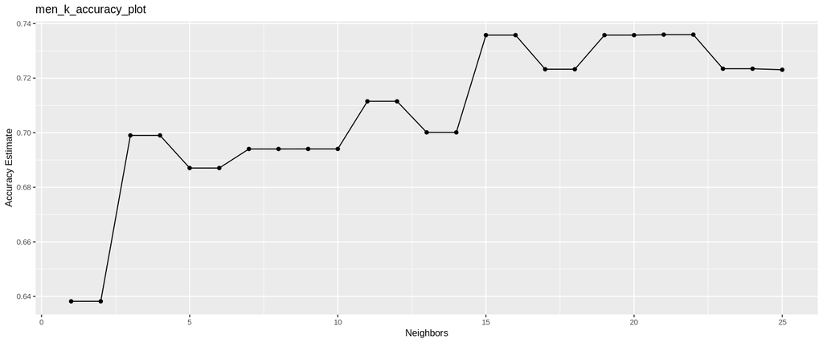

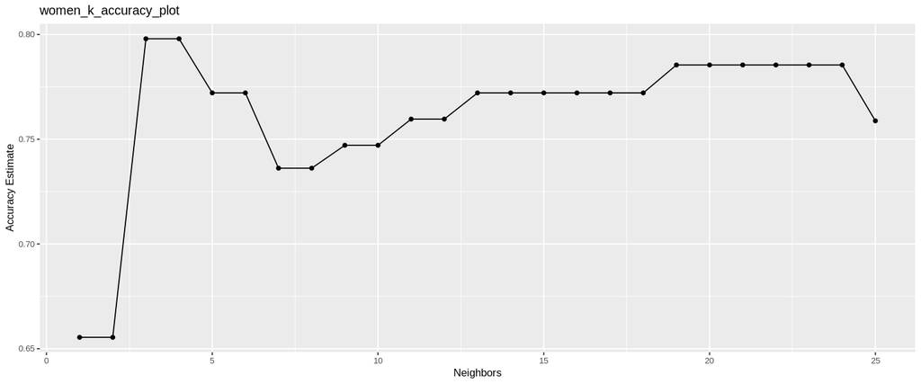

```r
options(repr.plot.width = 12)
men_k_accuracy_plot
women_k_accuracy_plot
```

*Graph 3.3.1 (Above) and 3.3.2 (Below): Graph of tables 3.2.1 and 3.2.2 respectively*

Here, we can see that see that the most accurate K value for men is around 19-22, while for woman it is around 3. We can find the most accurate value by arranging by accuracy and picking out the most accurate K value.

```r
men_k_best_accuracy <- men_k_accuracy %>%
    arrange(desc(mean)) %>%
    head(n = 1) %>%
    select(neighbors) %>%
    pull()
women_k_best_accuracy <- women_k_accuracy %>%
    arrange(desc(mean)) %>%
    head(n = 1) %>%
    select(neighbors) %>%
    pull()
```

```r
men_k_best_accuracy
women_k_best_accuracy
```

21

3

*Values 3.4.1 and 3.4.2: The best accuracy found from the graphs 3.3.1 and 3.3.2*

Having obtained the best accuracy values, we can now use them to test our vfold's accuracy. We'll do that using a fit and the collect_metrics function.

```r
create_fit <- function(k, rec, traindat) {
    knn_spec <- nearest_neighbor(weight_func = "rectangular", neighbors = k) %>%
        set_engine("kknn") %>%
        set_mode("classification")
    pfit <- workflow() %>%
        add_recipe(rec) %>%
        add_model(knn_spec) %>%
        fit(data = traindat)
}
prediction_accuracy <- function (pfit, testdat) {
    test_predictions <- predict(pfit, testdat) %>%
        bind_cols(testdat)
}
```

We then create a function that creates are K nearest neighbors classifer, sets k = to the one with the best accuracy, creates a model specification, ombine the model specification and recipe into a workflow, and then finally use fit with the training data to build the classifier. We then create a function that uses our K-nearest neighbour classifier object to predict the class labels for our test set. Bind_cols is used to add the column of predictions to the original test data.

```r
hd_men_fit <- create_fit(men_k_best_accuracy, men_recipe, men_training)
hd_women_fit <- create_fit(women_k_best_accuracy, women_recipe, women_training)
```

The functions created above are then applied to the men and women data frames.

```r
hd_men_metrics <- hd_men_fit %>%
    fit_resamples(resamples = vfold_men) %>%
    collect_metrics()
hd_women_metrics <- hd_women_fit %>%
    fit_resamples(resamples = vfold_women) %>%
    collect_metrics
```

We use the fit created to test our cross validation's accuracy

```r
hd_men_metrics
hd_women_metrics
```

A tibble: 2 × 5

| .metric <chr> | .estimator <chr> | mean <dbl> | n <int> | std_err <dbl> |
| --- | --- | --- | --- | --- |
| accuracy | binary | 0.7359514 | 5 | 0.02894290 |
| roc_auc | binary | 0.7936174 | 5 | 0.02744971 |

A tibble: 2 × 5

| .metric <chr> | .estimator <chr> | mean <dbl> | n <int> | std_err <dbl> |
| --- | --- | --- | --- | --- |
| accuracy | binary | 0.7979412 | 5 | 0.008766359 |
| roc_auc | binary | 0.7251136 | 5 | 0.049849823 |

*Table 3.5.1 and 3.5.2: The accuracy for the vfold constructed*

These accuracy values are high enough that we can be confident in proceeding and finishing our classification model.

So, we'll predict our testing data using the fit we created.

```r
men_prediction <- prediction_accuracy(hd_men_fit, men_testing)
women_prediction <- prediction_accuracy(hd_women_fit, women_testing)
```

```r
men_prediction_accuracy <- metrics(men_prediction, truth = num, estimate = .pred_class) %>%
    filter(.metric == "accuracy")
women_prediction_accuracy <- metrics(women_prediction, truth = num, estimate = .pred_class) %>%
    filter(.metric == "accuracy")
```

```r
men_prediction_accuracy
women_prediction_accuracy
```

A tibble: 1 × 3

| .metric <chr> | .estimator <chr> | .estimate <dbl> |
| --- | --- | --- |
| accuracy | binary | 0.725 |

A tibble: 1 × 3

| .metric <chr> | .estimator <chr> | .estimate <dbl> |
| --- | --- | --- |
| accuracy | binary | 0.7777778 |

*Table 3.6.1 and 3.6.2: Accuracy for the prediction model*

Our resulting classifier has an accuracy of 72.5% for men, and an accuracy for 77.7% for woman.

```r
men_confmat <- conf_mat(men_prediction, truth = num, estimate = .pred_class)
women_confmat <- conf_mat(women_prediction, truth = num, estimate = .pred_class)
```

```r
men_confmat
women_confmat
```

```
          Truth
Prediction  0  1
         0 12  5
         1  6 17
```

```
          Truth
Prediction  0  1
         0 12  2
         1  2  2
```

*Confusion Matrices 3.7.1 and 3.7.2: Comparison of prediction veracities*

### Discussion

##### Summary:

Our resulting classifier had an accuracy for 72.5% in men, as well as an accuracy for 77.7% in woman. Generally speaking, for circumstances as serious as human health, one would generally say that an accuracy of roughly 75, or 3/4 guesses would not be accurate enough. However, since we only use a select few variables in building our classifier that all record data through non-invasive means, this classifier may be useful if there is no other means to diagnose a patient.

We began our data analysis by removing all observations that were classification parameters rather than numerical ones. After that we found the variables that when analyzed brought about a plausible model for generating a classification system for heart disease. These are: blood pressure, cholesterol, age, maximum heart rate, and ST wave depression induced by exercise. The analysis followed that cholesterol increases blood pressure, which in turn increases ST wave depression. This variable is a measurement of strain on the heart induced by exercise. This, of course, correlates extremely well with the type of heart disease we are measuring, which is narrowing of major arteries, which in turn would put a major strain on the heart. Uniquely women are not as heavily affected by this variety of heart disease, and it seems to skew our model to appear more accurate due to the majority not having it. This may because that woman are twice as likely to have nonobstructive heart disease compared to men, and make up much of the undertreated population of heart disease pateints. This would explain why in *Table 2.1*, woman would appear to have a much higher tolerance to cholerterol and the diagnosis of heart disease. Since we classified our prediction to be based off of the narrowing of the major blood vessels, many woman would be underdiagnosed since they are much more susceptible to non-obstructive heart diseases than obstrutive. This woud explain why in our confusion matrix, only 2 woman are accurately diagnosed to have heart disease. There are many woman who may have non-obsctruvtive heart disease, but since our classifier only measures the narrowing of blood vessels, and classifies having heart disease as such, they would go untreated. However, there is evidence that non-obstructive heart disease are at the same risk of death due to heart attacks, stroke, or heart failure, as people with their major arteries blocked, which would explain why many woman with heart disease go untreated.

##### Expected outcomes and Significance:

We anticipated to find that high blood pressure, high cholesterol, and age to all be strongly linked. In graphs 2.2, 2.3, 2.4, we can see a positive weak correlation between all of them, meaning that they are less closely tied that we had anticipated. However, the relationship is there, which is to be expected since their values are typically reflective of a general lifestyle one lives. For example, the older you get, the less likely you are to exercise regularly and maintain a lower blood pressure. Additionally, we expected to find a positive relationship between blood pressure and the ST wave depression induced by exercise, since it intuitively makes sense for there to be a stronger strain when someone doesn't regularly exercise does do so, which we found to be true. Lastly, we had hypothesized that the there be physiological differences in men and woman which may skew our data, which we also found to be true in table 2.1 when we compared the cholersterol levels.

##### What impact could such findings have?

According to dieticians and researchers, heart disease is preventable and can be reversed. Moderate changes to diet can be enough to prevent it early on, and reversal can be achieved through cardiac rehabilitation. By noticing patterns and trends in easily tracked factors such as blood pressure and cholesterol levels, one can take the steps necessary to prevent or reverse the disease. Therefore, despite the innaccuacy of our classifier at around 75%, it uses numerical data that is relatively easy to collect. By more frequently checking up on these variables, an earliar diagnosis may be found which would leave more time for patients to receive treatment. Additionally, since many woman are being untreated since they are more vulenrable to non-obstructive heart disease than obstructive heart disease, different measurements and considerations should be used to diagnose woman.

##### What future questions could this lead to?

How do we accurately predict which individuals are more at risk of getting heart disease using more factors?  
What symptoms and factors are most strongly correlated to preventable/reversable heart disease?  
Which symptoms and factors most strongly correlate to early signs of heart disease?  
Why are woman twice as likely to have non-obstructive heart disease compared to men?

##### Conclusion:

By analyzing this data set, we hope to find and support the traditional narrative surrounding heart disease and its causes. Furthermore, we hope that this can give insight as to the aspects of our lives that most strongly impact our risk for heart disease, giving a guideline as to what to fix if you believe you are at risk.

#### Work Cited

“Cholesterol: Types, Tests, Treatments, Prevention.” Cleveland Clinic, 2012, my.clevelandclinic.org/health/articles/11920-cholesterol-numbers-what-do-they-mean. \ Download Limit Exceeded - Pennsylvania State University. citeseerx.ist.psu.edu/viewdoc/download?doi=10.1.1.403.9904&rep=rep1&type=pdf. \ “The Heart Responds Differently to Exercise in Men vs. Women.” American College of Cardiology, 27 Mar. 2014, www.acc.org/about-acc/press-releases/2014/03/27/12/29/allison-peak-hr-pr#:~:text=Women%20in%20the%20age%20range,93%20percent%20of%20their%20age. \ “The Heart Responds Differently to Exercise in Men vs. Women.” American College of Cardiology, 27 Mar. 2014, www.acc.org/about-acc/press-releases/2014/03/27/12/29/allison-peak-hr-pr#:~:text=Women%20in%20the%20age%20range,93%20percent%20of%20their%20age. \ “LDL Cholesterol & Heart Health.” Cleveland Clinic, my.clevelandclinic.org/health/articles/16866-cholesterol-guidelines--heart-health. \ Lutfi, Mohamed Faisal, and Mohamed Yosif Sukkar. “The Effect of Gender on Heart Rate Variability in Asthmatic and Normal Healthy Adults.” International Journal of Health Sciences, Qassim University, Kingdom of Saudi Arabia, July 2011, www.ncbi.nlm.nih.gov/pmc/articles/PMC3521833/. \ Maas, A H E M, and Y E A Appelman. “Gender Differences in Coronary Heart Disease.” Netherlands Heart Journal : Monthly Journal of the Netherlands Society of Cardiology and the Netherlands Heart Foundation, Bohn Stafleu Van Loghum, Dec. 2010, www.ncbi.nlm.nih.gov/pmc/articles/PMC3018605/#:~:text=Women%2C%20Risk%20Factors-,Cardiovascular%20disease%20develops%207%20to%2010%20years%20later%20in%20women,'protected'%20against%20cardiovascular%20disease. \ Michos, Erin Donnelly. “Why Cholesterol Matters for Women.” Johns Hopkins Medicine, www.hopkinsmedicine.org/health/wellness-and-prevention/why-cholesterol-matters-for-women#:~:text=So%20what%20are%20your%20target,200%20mg%2Fdl%20are%20best. \ Rawat, Shubhankar. “Heart Disease Prediction.” Medium, Towards Data Science, 28 June 2021, towardsdatascience.com/heart-disease-prediction-73468d630cfc. \ Rawat, Shubhankar. “Heart Disease Prediction.” Medium, Towards Data Science, 28 June 2021, towardsdatascience.com/heart-disease-prediction-73468d630cfc. \ “Target Heart Rates Chart.” Www.heart.org, 25 June 2021, www.heart.org/en/healthy-living/fitness/fitness-basics/target-heart-rates. \ “Updated Classification System Captures Many More People at Risk for Heart Attack - 01/11/2017.” Johns Hopkins Medicine, Based in Baltimore, Maryland, www.hopkinsmedicine.org/news/media/releases/updated_classification_system_captures_many_more_people_at_risk_for_heart_attack. \ “What Your Heart Rate Is Telling You.” Harvard Health, 30 Aug. 2020, www.health.harvard.edu/heart-health/what-your-heart-rate-is-telling-you. \ Yeo, Patricia Kelly, et al. “What Is High Cholesterol? Symptoms, Causes, Diagnosis, Treatment, and Prevention.” EverydayHealth.com, www.everydayhealth.com/high-cholesterol/guide/#:~:text=Men%20and%20premenopausal%20women%20have,higher%20HDL%20levels%20than%20men. \